# FinalProjectRMarkdown

Joe Margolis

12/17/2020

## Library Statements

```r
library(dplyr)
```

```r
library(readr)
library(ggplot2)
library(broom)
library(ggmosaic)
source('ggavplot.R')
# add library statements for other packages you may need
```

## Data Loading

```r
CollegeScores <- read_csv("Scorecard.csv")
head(CollegeScores)
```

```
## # A tibble: 6 x 93
##      X1 UNITID OPEID INSTNM CITY  STABBR ZIP    MAIN PREDDEG HIGHDEG CONTROL
##   <dbl>  <dbl> <chr> <chr>  <chr> <chr>  <chr> <dbl>   <dbl>   <dbl>   <dbl>
## 1     1 100654 0010… Alaba… Norm… AL     35762     1       3       4       1
## 2     2 100663 0010… Unive… Birm… AL     3529…     1       3       4       1
## 3     3 100690 0250… Amrid… Mont… AL     3611…     1       3       4       2
## 4     4 100706 0010… Unive… Hunt… AL     35899     1       3       4       1
## 5     5 100724 0010… Alaba… Mont… AL     3610…     1       3       4       1
## 6     6 100751 0010… The U… Tusc… AL     3548…     1       3       4       1
## # … with 82 more variables: ST_FIPS <dbl>, LOCALE <dbl>, LATITUDE <dbl>,
## #   LONGITUDE <dbl>, CCBASIC <dbl>, CCUGPROF <dbl>, CCSIZSET <dbl>, HBCU <dbl>,
## #   PBI <dbl>, ANNHI <dbl>, TRIBAL <dbl>, AANAPII <dbl>, HSI <dbl>,
## #   NANTI <dbl>, MENONLY <dbl>, WOMENONLY <dbl>, PCIP01 <dbl>, PCIP03 <dbl>,
## #   PCIP04 <dbl>, PCIP05 <dbl>, PCIP09 <dbl>, PCIP10 <dbl>, PCIP11 <dbl>,
## #   PCIP12 <dbl>, PCIP13 <dbl>, PCIP14 <dbl>, PCIP15 <dbl>, PCIP16 <dbl>,
## #   PCIP19 <dbl>, PCIP22 <dbl>, PCIP23 <dbl>, PCIP24 <dbl>, PCIP25 <dbl>,
## #   PCIP26 <dbl>, PCIP27 <dbl>, PCIP29 <dbl>, PCIP30 <dbl>, PCIP31 <dbl>,
## #   PCIP38 <dbl>, PCIP39 <dbl>, PCIP40 <dbl>, PCIP41 <dbl>, PCIP42 <dbl>,
## #   PCIP43 <dbl>, PCIP44 <dbl>, PCIP45 <dbl>, PCIP46 <dbl>, PCIP47 <dbl>,
## #   PCIP48 <dbl>, PCIP49 <dbl>, PCIP50 <dbl>, PCIP51 <dbl>, PCIP52 <dbl>,
## #   PCIP54 <dbl>, UGDS <dbl>, UGDS_WHITE <dbl>, UGDS_BLACK <dbl>,
## #   UGDS_HISP <dbl>, UGDS_ASIAN <dbl>, UGDS_AIAN <dbl>, UGDS_NHPI <dbl>,
## #   UGDS_2MOR <dbl>, UGDS_NRA <dbl>, UGDS_UNKN <dbl>, UGDS_MEN <dbl>,
## #   UGDS_WOMEN <dbl>, PPTUG_EF <dbl>, INEXPFTE <dbl>, TUITFTE <dbl>,
## #   DEBT_MDN <dbl>, GRAD_DEBT_MDN <dbl>, WDRAW_DEBT_MDN <dbl>,
## #   PELL_DEBT_MDN <dbl>, NOPELL_DEBT_MDN <dbl>, PCTPELL <dbl>, PCTFLOAN <dbl>,
## #   ICLEVEL <dbl>, AGE_ENTRY <dbl>, FEMALE <dbl>, FIRST_GEN <dbl>,
## #   FAMINC <dbl>, MD_EARN_WNE_P6 <dbl>
```

```r
CollegeScores <- CollegeScores %>%
  left_join(data.frame(region = state.region, STABBR = state.abb)) #Create new variable with states
CollegeScores <- CollegeScores %>%
  mutate(predegree = as.factor(PREDDEG))    #Quantitative to categorical
CollegeScores <- CollegeScores %>%
  mutate(degree = recode(predegree, '1' = "Certificate", '2' = "Associate", '3' = "Bachelors"))

CollegeScores <- CollegeScores %>%
  mutate(raceSchool = (HBCU + PBI + ANNHI + TRIBAL + AANAPII + HSI + NANTI) > 0)

CollegeScores<- CollegeScores %>%
  mutate(WageCat = cut(MD_EARN_WNE_P6, breaks=c(9100, 24600, 29300, 35900, 120500), labels=c("Low Quartile Wage ($9100-24600)","Low-Mid Quartile Wage ($24600-29300)","High-Mid Quartile Wage($29300-35900)","High Quartile Wage ($35900-120500")))

CollegeScores %>%
  count(degree)
```

```
## # A tibble: 3 x 2
##   degree          n
##   <fct>       <int>
## 1 Certificate   597
## 2 Associate    1090
## 3 Bachelors    1989
```

```r
CollegeScores %>%
  count(region)
```

```
## # A tibble: 5 x 2
##   region            n
##   <fct>         <int>
## 1 Northeast       749
## 2 South          1246
## 3 North Central   854
## 4 West            740
## 5 <NA>             87
```

## Create Linear Model

```r
lm.mod.full <- CollegeScores %>%
  with(lm(MD_EARN_WNE_P6 ~ region + degree + UGDS + TUITFTE))
```

## Look at model estimates

```r
tidy(lm.mod.full)
```

```
## # A tibble: 8 x 5
##   term                 estimate std.error statistic  p.value
##   <chr>                   <dbl>     <dbl>     <dbl>    <dbl>
## 1 (Intercept)         24759.     542.         45.6  0.
## 2 regionSouth         -3669.     422.         -8.70 5.02e-18
## 3 regionNorth Central  -927.     446.         -2.08 3.79e- 2
## 4 regionWest          -1526.     477.         -3.20 1.40e- 3
## 5 degreeAssociate      1654.     464.          3.57 3.68e- 4
## 6 degreeBachelors      8869.     451.         19.7  1.54e-81
## 7 UGDS                    0.167    0.0214      7.82 7.19e-15
## 8 TUITFTE                 0.236    0.0158     15.0  3.56e-49
```

> Based on a significance threshold of 0.05, all of these variables show a small enough p-value to display a significant relationship between the variable and the median wage earned six years after enrollment.

```r
lm.mod.sub <- CollegeScores %>%
  with(lm(MD_EARN_WNE_P6 ~ region + degree + TUITFTE))


anova(lm.mod.full, lm.mod.sub) # Compare nested models
```

```
## Analysis of Variance Table
##
## Model 1: MD_EARN_WNE_P6 ~ region + degree + UGDS + TUITFTE
## Model 2: MD_EARN_WNE_P6 ~ region + degree + TUITFTE
##   Res.Df        RSS Df   Sum of Sq      F   Pr(>F)
## 1   3254 2.3070e+11
## 2   3255 2.3504e+11 -1 -4333417897 61.122 7.19e-15 ***
## ---
## Signif. codes:  0 '***' 0.001 '**' 0.01 '*' 0.05 '.' 0.1 ' ' 1
```

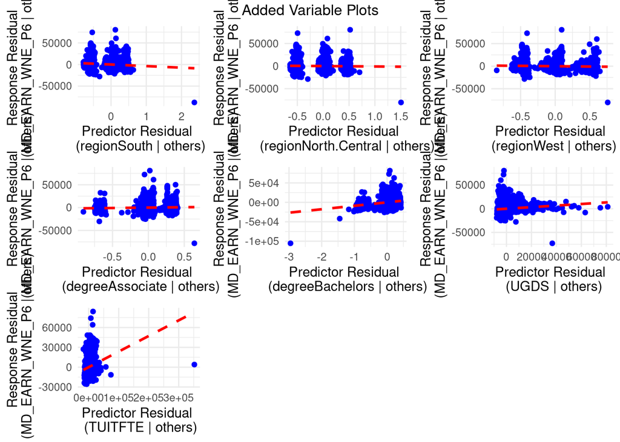

```r
mod1 <- CollegeScores %>%
  with(lm(MD_EARN_WNE_P6 ~ region + degree))
mod2 <- CollegeScores %>%
  with(lm(MD_EARN_WNE_P6 ~ region + degree + (region * degree)))

# Added Variable Plots
lm.mod.full %>%
  ggAVPLOTS()
```

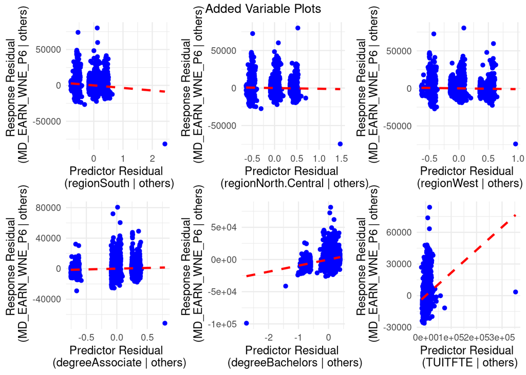

```r
lm.mod.sub %>%
  ggAVPLOTS()
```

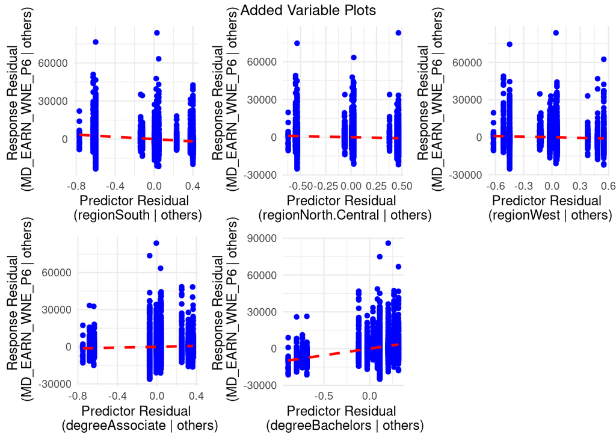

```r
mod1 %>%
  ggAVPLOTS()
```

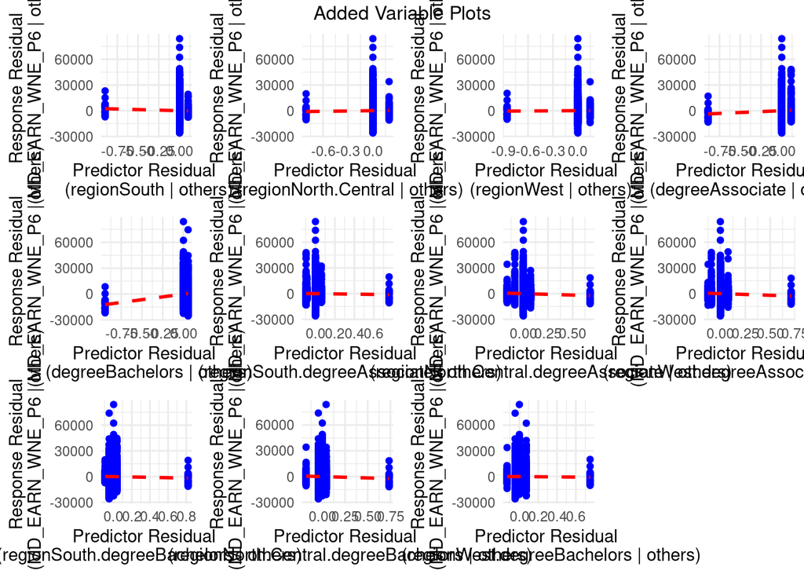

```r
mod2 %>%
  ggAVPLOTS()
```

> The added variable plot for the interaction variables of region and degree show redundancy for the region variables and the interaction variables, giving all the cusal effect to the degree variable

```r
#Numerical summaries and 95% cofidence intervals
summary(mod1)
```

```
##
## Call:
## lm(formula = MD_EARN_WNE_P6 ~ region + degree)
##
## Residuals:
##    Min     1Q Median     3Q    Max
## -26121  -4421  -1137   2607  83807
##
## Coefficients:
##                     Estimate Std. Error t value Pr(>|t|)
## (Intercept)          27465.1      533.9  51.443  < 2e-16 ***
## regionSouth          -4487.2      431.8 -10.391  < 2e-16 ***
## regionNorth Central  -1727.8      460.0  -3.757 0.000175 ***
## regionWest           -1653.1      490.2  -3.372 0.000755 ***
## degreeAssociate       1729.3      479.7   3.605 0.000317 ***
## degreeBachelors      10855.6      449.3  24.161  < 2e-16 ***
## ---
## Signif. codes:  0 '***' 0.001 '**' 0.01 '*' 0.05 '.' 0.1 ' ' 1
##
## Residual standard error: 8741 on 3256 degrees of freedom
##   (414 observations deleted due to missingness)
## Multiple R-squared:  0.2687, Adjusted R-squared:  0.2676
## F-statistic: 239.3 on 5 and 3256 DF,  p-value: < 2.2e-16
```

```r
confint(mod1)
```

```
##                          2.5 %     97.5 %
## (Intercept)         26418.3547 28511.9440
## regionSouth         -5333.9003 -3640.4513
## regionNorth Central -2629.6691  -826.0138
## regionWest          -2614.2431  -691.8666
## degreeAssociate       788.8089  2669.7303
## degreeBachelors      9974.6625 11736.5536
```

```r
summary(mod2)
```

```
##
## Call:
## lm(formula = MD_EARN_WNE_P6 ~ region + degree + (region * degree))
##
## Residuals:
##    Min     1Q Median     3Q    Max
## -26058  -4382  -1121   2609  83998
##
## Coefficients:
##                                     Estimate Std. Error t value Pr(>|t|)
## (Intercept)                          25350.0     1711.7  14.810  < 2e-16 ***
## regionSouth                          -2590.1     1807.1  -1.433   0.1519
## regionNorth Central                   1247.2     1908.4   0.654   0.5135
## regionWest                             545.3     1854.1   0.294   0.7687
## degreeAssociate                       4246.6     1817.0   2.337   0.0195 *
## degreeBachelors                      12907.8     1762.0   7.326 2.98e-13 ***
## regionSouth:degreeAssociate          -1585.3     1967.6  -0.806   0.4205
## regionNorth Central:degreeAssociate  -3397.1     2081.7  -1.632   0.1028
## regionWest:degreeAssociate           -3902.0     2032.1  -1.920   0.0549 .
## regionSouth:degreeBachelors          -2144.6     1889.4  -1.135   0.2564
## regionNorth Central:degreeBachelors  -3103.0     1995.8  -1.555   0.1201
## regionWest:degreeBachelors           -1013.7     1974.8  -0.513   0.6078
## ---
## Signif. codes:  0 '***' 0.001 '**' 0.01 '*' 0.05 '.' 0.1 ' ' 1
##
## Residual standard error: 8728 on 3250 degrees of freedom
##   (414 observations deleted due to missingness)
## Multiple R-squared:  0.2723, Adjusted R-squared:  0.2698
## F-statistic: 110.5 on 11 and 3250 DF,  p-value: < 2.2e-16
```

```r
confint(mod2)
```

```
##                                          2.5 %      97.5 %
## (Intercept)                         21993.8800 28706.12003
## regionSouth                         -6133.1996   953.02337
## regionNorth Central                 -2494.5249  4988.91739
## regionWest                          -3090.0331  4180.69974
## degreeAssociate                       683.9896  7809.18111
## degreeBachelors                      9453.0593 16362.53705
## regionSouth:degreeAssociate         -5443.1505  2272.61752
## regionNorth Central:degreeAssociate -7478.7474   684.46146
## regionWest:degreeAssociate          -7886.3354    82.32991
## regionSouth:degreeBachelors         -5849.0870  1559.92534
## regionNorth Central:degreeBachelors -7016.2041   810.15399
## regionWest:degreeBachelors          -4885.7345  2858.33942
```

```r
summary(lm.mod.full)
```

```
##
## Call:
## lm(formula = MD_EARN_WNE_P6 ~ region + degree + UGDS + TUITFTE)
##
## Residuals:
##    Min     1Q Median     3Q    Max
## -79166  -4029   -924   2613  80831
##
## Coefficients:
##                       Estimate Std. Error t value Pr(>|t|)
## (Intercept)          2.476e+04  5.425e+02  45.640  < 2e-16 ***
## regionSouth         -3.669e+03  4.216e+02  -8.704  < 2e-16 ***
## regionNorth Central -9.268e+02  4.463e+02  -2.077 0.037919 *
## regionWest          -1.526e+03  4.770e+02  -3.198 0.001397 **
## degreeAssociate      1.654e+03  4.640e+02   3.565 0.000368 ***
## degreeBachelors      8.869e+03  4.507e+02  19.678  < 2e-16 ***
## UGDS                 1.673e-01  2.140e-02   7.818 7.19e-15 ***
## TUITFTE              2.361e-01  1.575e-02  14.991  < 2e-16 ***
## ---
## Signif. codes:  0 '***' 0.001 '**' 0.01 '*' 0.05 '.' 0.1 ' ' 1
##
## Residual standard error: 8420 on 3254 degrees of freedom
##   (414 observations deleted due to missingness)
## Multiple R-squared:  0.3219, Adjusted R-squared:  0.3204
## F-statistic: 220.7 on 7 and 3254 DF,  p-value: < 2.2e-16
```

```r
confint(lm.mod.full)
```

```
##                             2.5 %        97.5 %
## (Intercept)         23695.5831655 25822.8793847
## regionSouth         -4495.5578715 -2842.4928900
## regionNorth Central -1801.8556113   -51.7183365
## regionWest          -2460.8806450  -590.2672347
## degreeAssociate       744.5560918  2563.9187112
## degreeBachelors      7984.9203551  9752.2539904
## UGDS                    0.1253213     0.2092216
## TUITFTE                 0.2052306     0.2669944
```

```r
summary(lm.mod.sub)
```

```
##
## Call:
## lm(formula = MD_EARN_WNE_P6 ~ region + degree + TUITFTE)
##
## Residuals:
##    Min     1Q Median     3Q    Max
## -73020  -4178   -838   2772  80492
##
## Coefficients:
##                       Estimate Std. Error t value Pr(>|t|)
## (Intercept)         25178.4647   544.7916  46.217  < 2e-16 ***
## regionSouth         -3556.7196   425.1794  -8.365  < 2e-16 ***
## regionNorth Central  -985.4961   450.3449  -2.188   0.0287 *
## regionWest          -1098.3368   478.2445  -2.297   0.0217 *
## degreeAssociate      1958.6316   466.5726   4.198 2.77e-05 ***
## degreeBachelors      9470.8115   448.1416  21.134  < 2e-16 ***
## TUITFTE                 0.2167     0.0157  13.804  < 2e-16 ***
## ---
## Signif. codes:  0 '***' 0.001 '**' 0.01 '*' 0.05 '.' 0.1 ' ' 1
##
## Residual standard error: 8498 on 3255 degrees of freedom
##   (414 observations deleted due to missingness)
## Multiple R-squared:  0.3092, Adjusted R-squared:  0.3079
## F-statistic: 242.8 on 6 and 3255 DF,  p-value: < 2.2e-16
```

```r
confint(lm.mod.sub)
```

```
##                             2.5 %        97.5 %
## (Intercept)         24110.2956310 26246.6336835
## regionSouth         -4390.3658562 -2723.0732730
## regionNorth Central -1868.4841693  -102.5080718
## regionWest          -2036.0275060  -160.6460807
## degreeAssociate      1043.8259313  2873.4371731
## degreeBachelors      8592.1433300 10349.4797119
## TUITFTE                 0.1858942     0.2474438
```

> The highest r-squared value is the lm.mod.full function with an r-squared value of 0.3219 The lowest residual standard error is also in the full model function of 8,420 on 3,254 degrees of freedom meaning that it has the lowest average variance from the predicted value by the model All of the variables, besides in the interaction model, show a p-value below the significance threshold of 0.05 and have confidence intervals that do not contain 0, pointing towards likely relationship between all the variables and the median wage earned 6 years after enrollment.

```r
final.lm.mod <-  CollegeScores %>%
  with(lm(MD_EARN_WNE_P6 ~ region + degree + UGDS + TUITFTE))

#Evaluate goodness of model
tidy(final.lm.mod)
```

```
## # A tibble: 8 x 5
##   term                 estimate std.error statistic  p.value
##   <chr>                   <dbl>     <dbl>     <dbl>    <dbl>
## 1 (Intercept)         24759.     542.         45.6  0.
## 2 regionSouth         -3669.     422.         -8.70 5.02e-18
## 3 regionNorth Central  -927.     446.         -2.08 3.79e- 2
## 4 regionWest          -1526.     477.         -3.20 1.40e- 3
## 5 degreeAssociate      1654.     464.          3.57 3.68e- 4
## 6 degreeBachelors      8869.     451.         19.7  1.54e-81
## 7 UGDS                    0.167    0.0214      7.82 7.19e-15
## 8 TUITFTE                 0.236    0.0158     15.0  3.56e-49
```

```r
confint(final.lm.mod)
```

```
##                             2.5 %        97.5 %
## (Intercept)         23695.5831655 25822.8793847
## regionSouth         -4495.5578715 -2842.4928900
## regionNorth Central -1801.8556113   -51.7183365
## regionWest          -2460.8806450  -590.2672347
## degreeAssociate       744.5560918  2563.9187112
## degreeBachelors      7984.9203551  9752.2539904
## UGDS                    0.1253213     0.2092216
## TUITFTE                 0.2052306     0.2669944
```

```r
glance(final.lm.mod)
```

```
## # A tibble: 1 x 12
##   r.squared adj.r.squared sigma statistic   p.value    df  logLik    AIC    BIC
##       <dbl>         <dbl> <dbl>     <dbl>     <dbl> <dbl>   <dbl>  <dbl>  <dbl>
## 1     0.322         0.320 8420.      221. 6.38e-269     7 -34108. 68234. 68288.
## # … with 3 more variables: deviance <dbl>, df.residual <int>, nobs <int>
```

## Create Logistic Model

```r
glm.mod.full <- CollegeScores %>%
  with(glm(raceSchool ~ MD_EARN_WNE_P6 + degree + region + UGDS, family = binomial))
```

## Hypothesis testing for logistic models

```r
tidy(glm.mod.full)
```

```
## # A tibble: 8 x 5
##   term                  estimate  std.error statistic  p.value
##   <chr>                    <dbl>      <dbl>     <dbl>    <dbl>
## 1 (Intercept)         -0.568     0.264          -2.15 3.14e- 2
## 2 MD_EARN_WNE_P6      -0.0000772 0.00000817     -9.45 3.33e-21
## 3 degreeAssociate      0.707     0.142           4.98 6.43e- 7
## 4 degreeBachelors      0.783     0.155           5.06 4.20e- 7
## 5 regionSouth          0.727     0.147           4.93 8.25e- 7
## 6 regionNorth Central -0.292     0.179          -1.63 1.04e- 1
## 7 regionWest           1.46      0.156           9.38 6.32e-21
## 8 UGDS                 0.0000579 0.00000635      9.13 7.05e-20
```

```r
glm.mod.sub <- CollegeScores %>%
  with(glm(raceSchool ~ MD_EARN_WNE_P6 + degree + UGDS + (region - region), family = binomial)) #Region-region part is to make sure it is using datasets of the same size

anova(glm.mod.full, glm.mod.sub, test='LRT') # Compare nested logistic models
```

```
## Analysis of Deviance Table
##
## Model 1: raceSchool ~ MD_EARN_WNE_P6 + degree + region + UGDS
## Model 2: raceSchool ~ MD_EARN_WNE_P6 + degree + UGDS + (region - region)
##   Resid. Df Resid. Dev Df Deviance  Pr(>Chi)
## 1      3254     2877.9
## 2      3257     3055.1 -3  -177.19 < 2.2e-16 ***
## ---
## Signif. codes:  0 '***' 0.001 '**' 0.01 '*' 0.05 '.' 0.1 ' ' 1
```

```r
logmod1 <- CollegeScores %>%
  with(glm(raceSchool ~ MD_EARN_WNE_P6 + degree, family = binomial))



logmod1 %>%
 augment(type.predict = 'response')
```

```
## # A tibble: 3,337 x 10
##    .rownames raceSchool MD_EARN_WNE_P6 degree .fitted .resid .std.resid    .hat
##    <chr>     <lgl>               <dbl> <fct>    <dbl>  <dbl>      <dbl>   <dbl>
##  1 1         TRUE                25200 Bache…   0.301  1.55       1.55  1.22e-3
##  2 2         FALSE               35100 Bache…   0.172 -0.614     -0.614 6.14e-4
##  3 3         TRUE                30700 Bache…   0.223  1.73       1.73  6.79e-4
##  4 4         FALSE               36200 Bache…   0.160 -0.591     -0.591 6.30e-4
##  5 5         TRUE                22600 Bache…   0.343  1.46       1.46  1.72e-3
##  6 6         FALSE               37400 Bache…   0.149 -0.568     -0.568 6.59e-4
##  7 7         FALSE               23100 Certi…   0.200 -0.669     -0.669 2.02e-3
##  8 8         FALSE               33400 Bache…   0.190 -0.650     -0.650 6.10e-4
##  9 9         TRUE                30100 Bache…   0.231  1.71       1.71  7.10e-4
## 10 10        FALSE               39500 Bache…   0.130 -0.528     -0.528 7.26e-4
## # … with 3,327 more rows, and 2 more variables: .sigma <dbl>, .cooksd <dbl>
```

[figure not shown]

```r
# Prediced Probability Boxplot
logmod1 %>%
  augment(type.predict = 'response') %>%
  ggplot(aes(y = .fitted, x = raceSchool)) +
  geom_boxplot() +
  ylab('Predicted Probability of Being a Minority Serving Institution') +
  xlab('Actual Type of School (False = Minority Serving Institution, True = Regular University)') +
  theme_classic()
```

```r
# Find false positive and false negatives
logmod1 %>%
  augment(type.predict = 'response') %>%
  mutate(predictRaceSchool = .fitted >= 0.22) %>%
  count(raceSchool, predictRaceSchool)
```

```
## # A tibble: 4 x 3
##   raceSchool predictRaceSchool     n
##   <lgl>      <lgl>             <int>
## 1 FALSE      FALSE              1533
## 2 FALSE      TRUE               1081
## 3 TRUE       FALSE               269
## 4 TRUE       TRUE                454
```

```r
glm.mod.full %>%
 augment(type.predict = 'response')
```

```
## # A tibble: 3,262 x 12
##    .rownames raceSchool MD_EARN_WNE_P6 degree region  UGDS .fitted .resid
##    <chr>     <lgl>               <dbl> <fct>  <fct>  <dbl>   <dbl>  <dbl>
##  1 1         TRUE                25200 Bache… South   4990   0.328  1.49
##  2 2         FALSE               35100 Bache… South  13186   0.268 -0.790
##  3 3         TRUE                30700 Bache… South    351   0.196  1.80
##  4 4         FALSE               36200 Bache… South   7458   0.194 -0.658
##  5 5         TRUE                22600 Bache… South   3903   0.360  1.43
##  6 6         FALSE               37400 Bache… South  32177   0.479 -1.14
##  7 7         FALSE               23100 Certi… South   1211   0.174 -0.619
##  8 8         FALSE               33400 Bache… South   2732   0.186 -0.641
##  9 9         TRUE                30100 Bache… South   4529   0.246  1.67
## 10 10        FALSE               39500 Bache… South  24147   0.330 -0.894
## # … with 3,252 more rows, and 4 more variables: .std.resid <dbl>, .hat <dbl>,
## #   .sigma <dbl>, .cooksd <dbl>
```

[figure not shown]

```r
glm.mod.full %>%
  augment(type.predict = 'response') %>%
  ggplot(aes(y = .fitted, x = raceSchool)) +
  geom_boxplot() +
  ylab('Predicted Probability of Being a Minority Serving Institution') +
  xlab('Actual Type of School (False = Minority Serving Institution, True = Regular University)') +
  theme_classic()
```

```r
glm.mod.full %>%
  augment(type.predict = 'response') %>%
  mutate(predictRaceSchool = .fitted >= 0.23) %>%
  count(raceSchool, predictRaceSchool)
```

```
## # A tibble: 4 x 3
##   raceSchool predictRaceSchool     n
##   <lgl>      <lgl>             <int>
## 1 FALSE      FALSE              1826
## 2 FALSE      TRUE                759
## 3 TRUE       FALSE               249
## 4 TRUE       TRUE                428
```

```r
glm.mod.sub %>%
 augment(type.predict = 'response')
```

```
## # A tibble: 3,262 x 12
##    .rownames raceSchool MD_EARN_WNE_P6 degree  UGDS region .fitted .resid
##    <chr>     <lgl>               <dbl> <fct>  <dbl> <fct>    <dbl>  <dbl>
##  1 1         TRUE                25200 Bache…  4990 South    0.293  1.57
##  2 2         FALSE               35100 Bache… 13186 South    0.245 -0.749
##  3 3         TRUE                30700 Bache…   351 South    0.159  1.92
##  4 4         FALSE               36200 Bache…  7458 South    0.165 -0.600
##  5 5         TRUE                22600 Bache…  3903 South    0.323  1.50
##  6 6         FALSE               37400 Bache… 32177 South    0.505 -1.19
##  7 7         FALSE               23100 Certi…  1211 South    0.185 -0.639
##  8 8         FALSE               33400 Bache…  2732 South    0.151 -0.573
##  9 9         TRUE                30100 Bache…  4529 South    0.211  1.76
## 10 10        FALSE               39500 Bache… 24147 South    0.327 -0.890
## # … with 3,252 more rows, and 4 more variables: .std.resid <dbl>, .hat <dbl>,
## #   .sigma <dbl>, .cooksd <dbl>
```

[figure not shown]

```r
glm.mod.sub %>%
  augment(type.predict = 'response') %>%
  ggplot(aes(y = .fitted, x = raceSchool)) +
  geom_boxplot() +
  ylab('Predicted Probability of Being a Minority Serving Institution') +
  xlab('Actual Type of School (False = Minority Serving Institution, True = Regular University)') +
  theme_classic()
```

```r
glm.mod.sub %>%
  augment(type.predict = 'response') %>%
  mutate(predictRaceSchool = .fitted >= 0.23) %>%
  count(raceSchool, predictRaceSchool)
```

```
## # A tibble: 4 x 3
##   raceSchool predictRaceSchool     n
##   <lgl>      <lgl>             <int>
## 1 FALSE      FALSE              1798
## 2 FALSE      TRUE                787
## 3 TRUE       FALSE               257
## 4 TRUE       TRUE                420
```

> logmod1: False Positive: 1081/2614 = 0.41 False Negative: 269/723 = 0.37 True Positive: 454/723 = 0.63 True Negative: 1533/2614 = 0.59 Accuracy: 1987/3337 = 0.595

> glm.mod.full: False Positive: 759/2585 = 0.29 False Negative: 249/677 = 0.37 True Positive: 428/677 = 0.63 True Negative: 1826/2585 = 0.71 Accuracy: 2254/3262 = 0.691

> glm.mod.sub: False Positive: 787/2585 = 0.30 False Negative: 257/677 = 0.38 True Positive: 420/677 = 0.62 True Negative: 1798/2585 = 0.70 Accuracy: 2218/3262 = 0.680

```r
final.glm.mod <- CollegeScores %>%
  with(glm(raceSchool ~ MD_EARN_WNE_P6 + degree + UGDS, family = binomial))

# Exponentiated Estimates and confidence intervals for logistic models
coef(final.glm.mod) %>% exp()
```

```
##     (Intercept)  MD_EARN_WNE_P6 degreeAssociate degreeBachelors            UGDS
##       1.8784265       0.9999039       1.7536947       2.0318937       1.0000718
```

```r
confint(final.glm.mod) %>% exp()
```

```
##                     2.5 %    97.5 %
## (Intercept)     1.2611266 2.8056362
## MD_EARN_WNE_P6  0.9998889 0.9999185
## degreeAssociate 1.3473757 2.2963345
## degreeBachelors 1.5361594 2.7045886
## UGDS            1.0000595 1.0000844
```

[figure not shown]

```r
augment(final.glm.mod, type.predict = 'response') %>%
  ggplot(aes(x = factor(raceSchool), y = .fitted)) +
  geom_boxplot() +
  labs(x = 'Type of School (False = Minority Serving, True = Normal School)', y = 'Predicted Probability of a School being a Minority Serving Institution') +
  theme_classic()
```

## Linear Model Visualizations

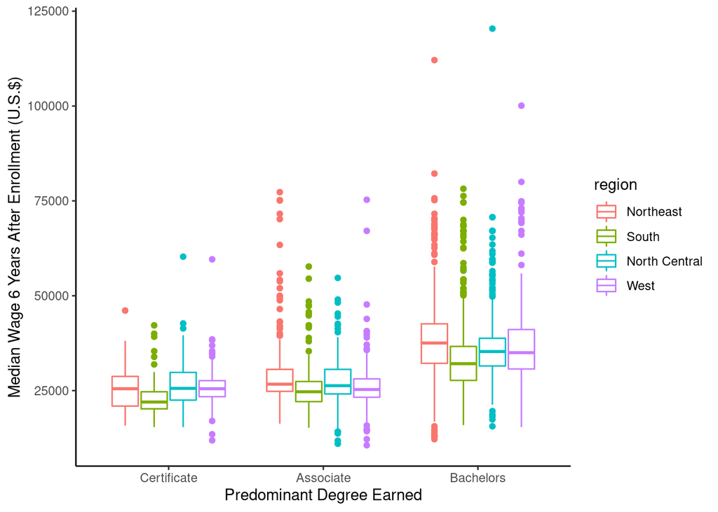

```r
#Side by Side boxplots (Quantitative outcome, two categorical explanatory)
CollegeScores %>%
  filter(!is.na(region)) %>%
  ggplot(aes(y = MD_EARN_WNE_P6, x = degree, color = region)) +
  geom_boxplot() +
  labs(y = "Median Wage 6 Years After Enrollment (U.S.$)", x = "Predominant Degree Earned") +
  theme_minimal() +
  theme_classic()
```

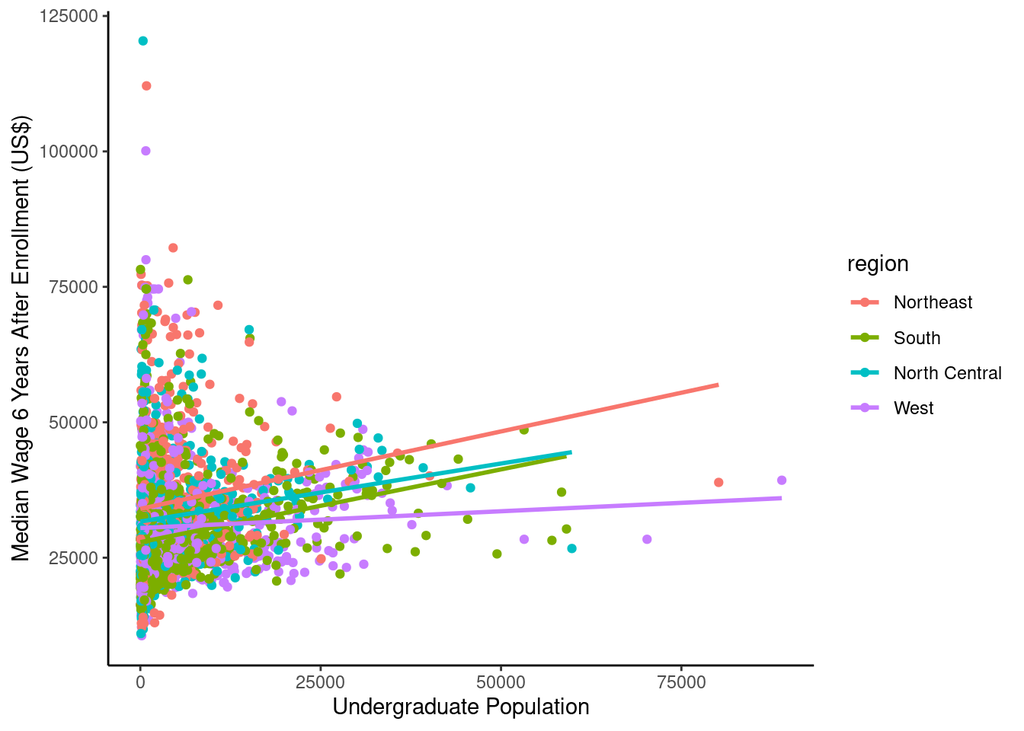

```r
# Scatter Plot (quantitative outcome, one categorical one explanatory variable)
CollegeScores %>%
  filter(!is.na(region)) %>%
  ggplot(aes(y = MD_EARN_WNE_P6, x = UGDS, color = region)) +
  geom_point() +
  geom_smooth(method = 'lm', se = FALSE) +
  labs(y = "Median Wage 6 Years After Enrollment (US$)", x = "Undergraduate Population") +
  theme_minimal() +
  theme_classic()
```

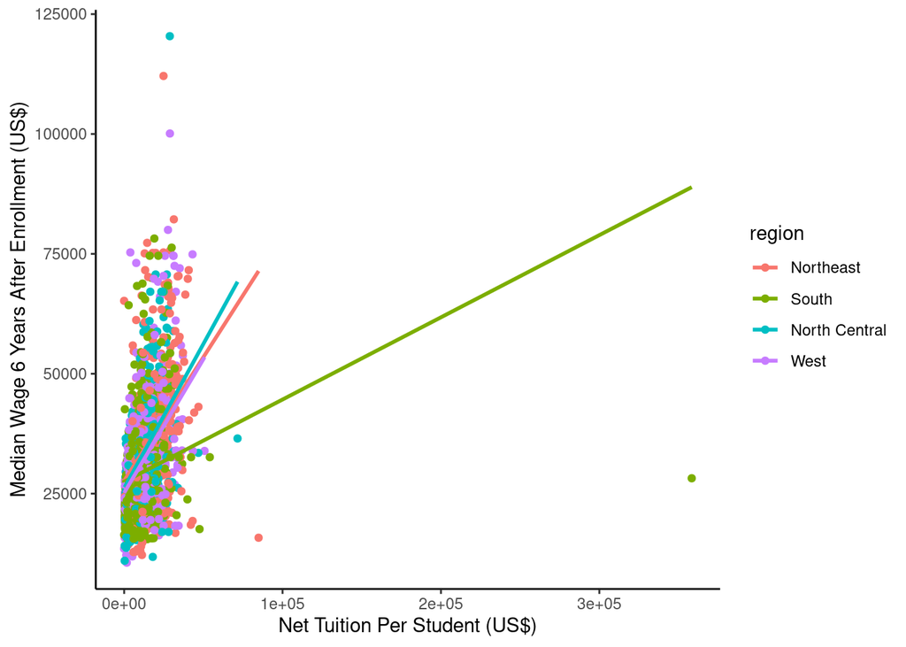

```r
# Scatter Plot
CollegeScores %>%
  filter(!is.na(region)) %>%
  ggplot(aes(y = MD_EARN_WNE_P6, x = TUITFTE, color = region)) +
  geom_point() +
  geom_smooth(method = 'lm', se = FALSE) +
  labs(y = "Median Wage 6 Years After Enrollment (US$)", x = "Net Tuition Per Student (US$)") +
  theme_minimal() +
  theme_classic()
```

```r
tidy(final.lm.mod) # estimates, standard errors, p-values
```

```
## # A tibble: 8 x 5
##   term                 estimate std.error statistic  p.value
##   <chr>                   <dbl>     <dbl>     <dbl>    <dbl>
## 1 (Intercept)         24759.     542.         45.6  0.
## 2 regionSouth         -3669.     422.         -8.70 5.02e-18
## 3 regionNorth Central  -927.     446.         -2.08 3.79e- 2
## 4 regionWest          -1526.     477.         -3.20 1.40e- 3
## 5 degreeAssociate      1654.     464.          3.57 3.68e- 4
## 6 degreeBachelors      8869.     451.         19.7  1.54e-81
## 7 UGDS                    0.167    0.0214      7.82 7.19e-15
## 8 TUITFTE                 0.236    0.0158     15.0  3.56e-49
```

```r
confint(final.lm.mod) # confidence intervals
```

```
##                             2.5 %        97.5 %
## (Intercept)         23695.5831655 25822.8793847
## regionSouth         -4495.5578715 -2842.4928900
## regionNorth Central -1801.8556113   -51.7183365
## regionWest          -2460.8806450  -590.2672347
## degreeAssociate       744.5560918  2563.9187112
## degreeBachelors      7984.9203551  9752.2539904
## UGDS                    0.1253213     0.2092216
## TUITFTE                 0.2052306     0.2669944
```

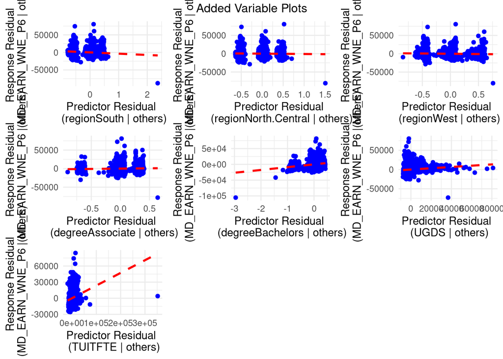

```r
final.lm.mod %>%
  ggAVPLOTS()
```

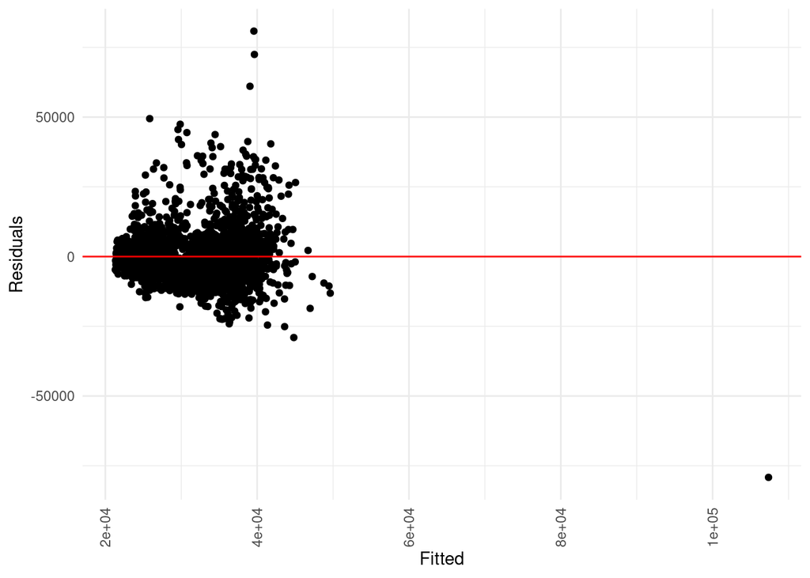

```r
# Residual plot of linear model
augment(final.lm.mod) %>%
    ggplot(aes(x = .fitted , y =.resid)) +
    geom_point()+
    labs(x = 'Fitted',y = 'Residuals') +
    theme_minimal()+
    geom_hline(yintercept= 0, color = "red")+
    theme(axis.text.x = element_text(angle = 90, vjust=0.5, hjust=1))
```

```r
glance(final.lm.mod) # to evaluate goodness
```

```
## # A tibble: 1 x 12
##   r.squared adj.r.squared sigma statistic   p.value    df  logLik    AIC    BIC
##       <dbl>         <dbl> <dbl>     <dbl>     <dbl> <dbl>   <dbl>  <dbl>  <dbl>
## 1     0.322         0.320 8420.      221. 6.38e-269     7 -34108. 68234. 68288.
## # … with 3 more variables: deviance <dbl>, df.residual <int>, nobs <int>
```

## Logistic Model Visualization

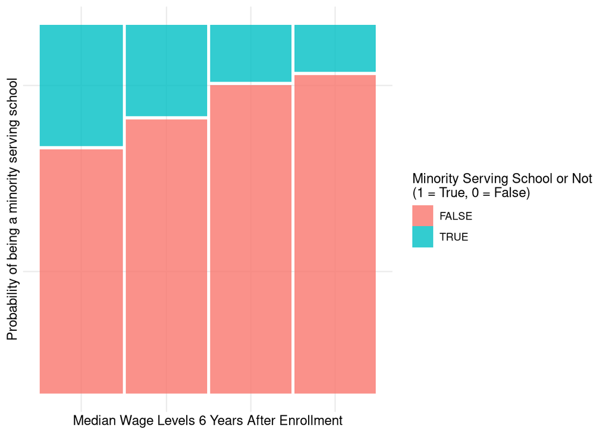

```r
# Stacked bar plot (Binary outcome, Categorical explanatory)

CollegeScores %>%
  mutate(WageCat = cut(MD_EARN_WNE_P6, breaks=c(9100, 24600, 29300, 35900, 120500), labels=c("Low Wage ($9100-24600)","Low-Mid Wage ($24600-29300)","High-Mid Wage($29300-35900)","High Wage ($35900-120500"))) %>%
 filter(!is.na(WageCat)) %>%
  ggplot() +
  geom_mosaic(aes(x = product(raceSchool, WageCat), fill = raceSchool)) +
  labs(x = 'Median Wage Levels 6 Years After Enrollment',
       y = 'Probability of being a minority serving school',
       fill = 'Minority Serving School or Not \n(1 = True, 0 = False)'
       ) +
  theme(axis.text.x = element_text(angle = 90, vjust=0.5, hjust=1)) +
  theme_minimal()
```

```r
# should have fit final.glm.mod in Part 1

coef(final.glm.mod) %>% exp() # exp estimates
```

```
##     (Intercept)  MD_EARN_WNE_P6 degreeAssociate degreeBachelors            UGDS
##       1.8784265       0.9999039       1.7536947       2.0318937       1.0000718
```

```r
confint(final.glm.mod) %>% exp() # confidence intervals
```

```
##                     2.5 %    97.5 %
## (Intercept)     1.2611266 2.8056362
## MD_EARN_WNE_P6  0.9998889 0.9999185
## degreeAssociate 1.3473757 2.2963345
## degreeBachelors 1.5361594 2.7045886
## UGDS            1.0000595 1.0000844
```

```r
tidy(final.glm.mod) # p-values
```

```
## # A tibble: 5 x 5
##   term              estimate  std.error statistic  p.value
##   <chr>                <dbl>      <dbl>     <dbl>    <dbl>
## 1 (Intercept)      0.630     0.204           3.09 1.99e- 3
## 2 MD_EARN_WNE_P6  -0.0000961 0.00000755    -12.7  4.30e-37
## 3 degreeAssociate  0.562     0.136           4.13 3.58e- 5
## 4 degreeBachelors  0.709     0.144           4.92 8.82e- 7
## 5 UGDS             0.0000718 0.00000634     11.3  9.26e-30
```

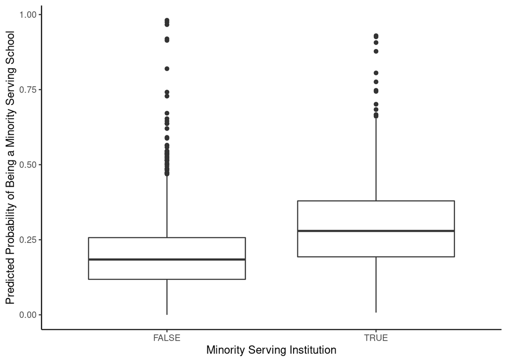

```r
# Predicted Probability Boxplots
augment(final.glm.mod, type.predict = 'response') %>%
  ggplot(aes(x = factor(raceSchool), y = .fitted)) + #replace ... with outcome variable name
  geom_boxplot() +
  labs(x = 'Minority Serving Institution', y = 'Predicted Probability of Being a Minority Serving School') +
  theme_classic()
```

```r
# False positive/negative
# evaluate goodness
threshold <- 0.23

augment(final.glm.mod, type.predict = 'response') %>%
  mutate(PredictOutcome = .fitted > threshold) %>%
  count(raceSchool, PredictOutcome) %>%
  group_by(raceSchool) %>%
  mutate(prop = n/sum(n))
```

```
## # A tibble: 4 x 4
## # Groups:   raceSchool [2]
##   raceSchool PredictOutcome     n  prop
##   <lgl>      <lgl>          <int> <dbl>
## 1 FALSE      FALSE           1739 0.665
## 2 FALSE      TRUE             875 0.335
## 3 TRUE       FALSE            263 0.364
## 4 TRUE       TRUE             460 0.636
```